# Level of Activity and Demographic Variables

Level of Activity and Demographic Variables

Go Back

## Project Overview

This project utilized accelerometer data collected on 250 participants in the NHANES study, or the `accel` dataset. The demographic dataset is accessible from [HERE](https://p8105.com/data/nhanes_covar.csv), and the accelerometer data is accessible from [HERE](https://p8105.com/data/nhanes_accel.csv). The project utilized R version 4.3.1 and R packages `dplyr`, `ggplot2`, and `tidyverse`.

After cleaning, final dataset includes all originally observed variables; participants less than 21 years of age or with missing demographic data are excluded.

There are 228 participants in the study, and the merged dataset has 1445 variables, after excluding participants less than 21 years of age and those with missing demographic data.

## Visualizations and EDA

#### Table of gender distribution in each education category

| education | sex | n_obs |
| --- | --- | --- |
| Less than high school | female | 28 |
| Less than high school | male | 27 |
| High school equivalent | female | 23 |
| High school equivalent | male | 35 |
| More than high school | female | 59 |
| More than high school | male | 56 |

Based on the table, for education levels of *Less than high school* and *More than high school*, male and female have similar number of participants. For *High school equivalent* education level, however, there are much more males compared to females.

#### Box Plot of age distributions in each education category, by gender

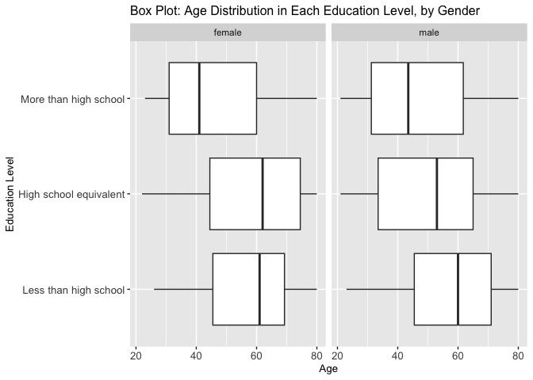

## Total Activity over the Day

#### Distribution of total activity over day by age, gender, and education level

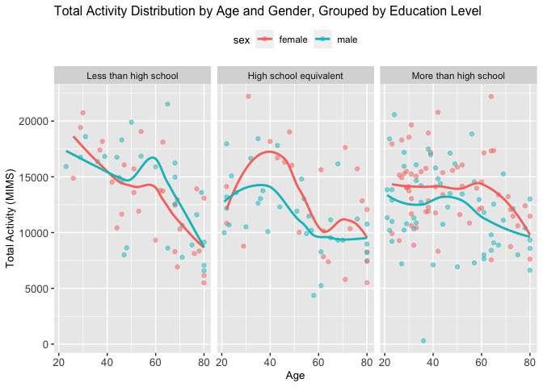

Overall, total activity decreases as age increases, consistent across all education levels and genders. This trend is most apparent among those with less than high school education, and least apparent among those with more than high school education.

For those with less than high school education, total activity decreases as age proceed from 21 to 50, then increases as age proceed from 50 to 60, then decreases again as age continues to increase. Males have more increase from age 50 to 60 than female.

For those with high school equivalent education, total activity increases as age proceed from 21 to 40, then decreases as age continues to proceed. For females, total activity increases again from age 60 to 70, then decreases again. For males, total activity plateaus starting age 60.

#### 24-hour activity time courses by education level and gender

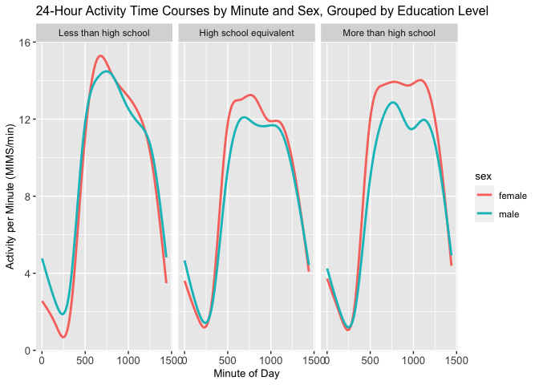

The activity peak for those with less than high school education is highest for both genders compared to the other two education level groups. This group decreases sharply after it reaches its peak activity level, consistent across genders.